# Assignment 2 – Behance Like Prediction

## 1. Predictive Task & Evaluation

### Task formulation (Context)

Our goal is to **predict which Behance projects a user will “appreciate” (like)** in the future, based on their past implicit feedback.

- **Input data:** triples of the form ((u, i, t)), where:
  - (u) is a user ID
  - (i) is a project (item) ID
  - (t) is a timestamp of when the user appreciated the project
- **Prediction task:** for a given user (u), and a set of candidate projects, we want to produce a **ranking** so that items the user actually appreciates are ranked as highly as possible.
- **Supervision type:** this is an **implicit-feedback recommendation** problem (we only see positive interactions, not explicit ratings or true negatives).

In our experiments, we evaluate a scoring function (s(u, i)) on **one positive project** and **100 sampled negatives** for each user in the validation/test sets. The model’s job is to assign higher scores to the positive project than to the negatives.

### Inputs, outputs, and what is optimized

- **Model inputs:**
  - A user index (u)
  - A project index (i)
  - Optionally, an image feature vector for project (i) (in the visual and hybrid models)
- **Model output:**
  - A **real-valued score** (s(u, i)). Higher scores mean “more likely that user (u) will appreciate project (i).”
- **Optimization objective:**
  - For the **matrix factorization (MF)** model, we optimize a **logistic loss** over positive and sampled negative user–item pairs, with (L_2) regularization on user and item embeddings.
  - For the **visual and hybrid** models, parameters are not learned directly in this notebook; instead, we combine precomputed image features with learned MF scores and tune a combination weight (alpha) using validation performance.

### Evaluation metrics

We evaluate models using two ranking metrics computed over each user’s 1 positive + 100 sampled negatives:

- **AUC (Area Under the ROC Curve):**
  - Interpreted here as (P(s(u, i_{pos}) > s(u, i_{neg}))) averaged over negatives.
  - Measures how often the model ranks the true positive above a random negative.
- **Precision@10 (P@10):**
  - For each user, we rank the 1 positive + 100 negatives, take the **top 10**, and check whether the positive is inside that top-10 set.
  - This approximates a practical scenario where we show the user a **small recommendation list** and ask whether it contains something they actually appreciated.

We report both metrics because:

- **AUC** captures overall ranking quality across all 101 items.
- **P@10** focuses on the **very top of the ranking**, which is often the most important region for a recommender system’s UI.

These evaluation choices are consistent with our goal: **produce a ranked list where true future appreciations appear near the top.**

## 2. Exploratory Data Analysis (EDA)

```python
# --- Core ---
import os, math, random, struct
from collections import defaultdict, Counter

# --- Data ---
import numpy as np
import pandas as pd

# --- Visualization ---
import matplotlib.pyplot as plt
import seaborn as sns
sns.set(style="whitegrid")

# --- ML helpers ---
from sklearn.decomposition import PCA

# --- Utils ---
from tqdm import tqdm
from numpy.linalg import norm

random.seed(0)
np.random.seed(0)
```

## Data Loading & Preprocessing

### Load appreciates file

```python
data_dir = "data"
path = os.path.join(data_dir, "Behance_appreciate_1M.gz")

triples_raw = []
with open(path, "rt") as f:
    for line in f:
        u, i, t = line.strip().split()
        triples_raw.append((u, i, int(t)))

len(triples_raw), triples_raw[:5]
```

```
(1000000,
 [('276633', '01588231', 1307583271),
  ('1238354', '01529213', 1307583273),
  ('165550', '00485000', 1307583337),
  ('2173258', '00776972', 1307583340),
  ('165550', '00158226', 1307583406)])
```

### Map users/items to integer indices

```python
user2idx, item2idx = {}, {}
idx2user, idx2item = [], []

triples = []  # (u_idx, i_idx, timestamp)

for u, i, t in triples_raw:
    if u not in user2idx:
        user2idx[u] = len(user2idx)
        idx2user.append(u)
    if i not in item2idx:
        item2idx[i] = len(item2idx)
        idx2item.append(i)
    triples.append((user2idx[u], item2idx[i], t))

num_users = len(user2idx)
num_items = len(item2idx)
num_users, num_items, len(triples)
```

```
(63497, 178788, 1000000)
```

### Train / val / test split (per user)

```python
by_user = defaultdict(list)
for u, i, t in triples:
    by_user[u].append((t, i))

train_pos = []
val_pos   = []
test_pos  = []

for u, lst in by_user.items():
    lst.sort()  # sort by time
    if len(lst) >= 3:
        *train_items, val_item, test_item = lst
        train_pos.extend((u, i) for (_, i) in train_items)
        val_pos.append((u, val_item[1]))
        test_pos.append((u, test_item[1]))
    elif len(lst) == 2:
        (t1, i1), (t2, i2) = lst
        train_pos.append((u, i1))
        test_pos.append((u, i2))
    else:
        train_pos.append((u, lst[0][1]))

len(train_pos), len(val_pos), len(test_pos)
```

```
(913270, 39171, 47559)
```

### Users' liked items

```python
user_pos_items = defaultdict(set)
for u, i in train_pos + val_pos + test_pos:
    user_pos_items[u].add(i)
```

### Negative sampling + eval data builder

```python
def sample_negative(u):
    """Sample an item that user u has NOT liked."""
    while True:
        j = random.randrange(num_items)
        if j not in user_pos_items[u]:
            return j

def build_eval_data(pos_pairs, num_neg=100):
    """
    pos_pairs: list of (u, i_pos).
    Returns: list of dicts: {"u": u, "pos": i_pos, "negs": [neg_items]}
    """
    eval_data = []
    for u, i_pos in pos_pairs:
        negs = [sample_negative(u) for _ in range(num_neg)]
        eval_data.append({"u": u, "pos": i_pos, "negs": negs})
    return eval_data

val_data  = build_eval_data(val_pos,  num_neg=100)
test_data = build_eval_data(test_pos, num_neg=100)

len(val_data), len(test_data)
```

```
(39171, 47559)
```

### Basic stats

```python
num_interactions = len(triples)
print("Users:", num_users)
print("Items:", num_items)
print("Interactions:", num_interactions)
print("Train/Val/Test:", len(train_pos), len(val_pos), len(test_pos))
```

```
Users: 63497
Items: 178788
Interactions: 1000000
Train/Val/Test: 913270 39171 47559
```

### Likes per user

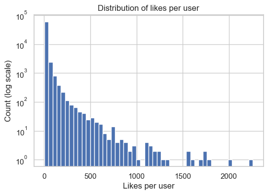

```python
user_counts = Counter(u for u, _, _ in triples)
plt.figure(figsize=(6,4))
plt.hist(list(user_counts.values()), bins=50)
plt.yscale("log")
plt.xlabel("Likes per user")
plt.ylabel("Count (log scale)")
plt.title("Distribution of likes per user")
plt.show()
```

### Likes per item

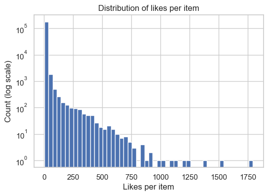

```python
item_counts_full = Counter(i for _, i, _ in triples)
plt.figure(figsize=(6,4))
plt.hist(list(item_counts_full.values()), bins=50)
plt.yscale("log")
plt.xlabel("Likes per item")
plt.ylabel("Count (log scale)")
plt.title("Distribution of likes per item")
plt.show()
```

## 3. Modeling

## 3. Modeling

In this section we define and implement several models for Behance like prediction:

1. A **popularity baseline** that ignores users and ranks projects by how many likes they have.
2. A **matrix factorization (MF)** model that learns user and item embeddings from interaction data.
3. A **visual-only** model that uses image features to build a visual profile for each user.
4. A **hybrid** model that combines the MF and visual scores with a weighted average.

For each model, we show the code first, followed immediately by a short description of what the model is doing and why we use it.

### 3.2 Popularity baseline

```python
item_counts = Counter(i for (u, i) in train_pos)

def pop_score(u, i):
    """
    Popularity-based score: returns how often item i was liked in the training data.
    Same score for all users.
    """
    return item_counts[i]
```

**Description (Popularity baseline)**  
The popularity baseline is a very simple recommendation strategy: it ranks all projects by how many times they were appreciated in the training set and recommends the same top projects to everyone.

- For each item (i), we count how many times it appears in the training positives.
- The scoring function `pop_score(u, i)` just returns this count, independent of the user (u).
- At evaluation time, higher counts mean higher ranks.

This model is useful because it is extremely fast and often surprisingly strong on platforms where attention is highly concentrated on a small number of very popular items.

### 3.3 Matrix factorization (MF)

```python
def build_mf_training_data(num_neg_per_pos=2):
    """
    Build training triples (u, i, y) for MF:
      - y = 1 for observed (positive) interactions
      - y = 0 for sampled negative items for the same user
    """
    data = []
    for u, i in train_pos:
        # positive example
        data.append((u, i, 1))
        # negative examples
        for _ in range(num_neg_per_pos):
            j = sample_negative(u)
            data.append((u, j, 0))
    random.shuffle(data)
    return data

mf_train_data = build_mf_training_data(num_neg_per_pos=2)
len(mf_train_data)
```

```
2739810
```

```python
K = 40        # latent dimension
lr = 0.05
reg = 0.005
epochs = 20

P = 0.01 * np.random.randn(num_users, K)  # user embeddings
Q = 0.01 * np.random.randn(num_items, K)  # item embeddings

# user and item bias terms
bu = np.zeros(num_users)
bi = np.zeros(num_items)

def mf_score(u, i):
    """
    MF score: user/item biases + dot product between latent factors.
    """
    return float(bu[u] + bi[i] + P[u] @ Q[i])
```

```python
def train_mf(train_data, epochs=5, lr=0.05, reg=0.001):
    """
    Train MF with logistic loss and L2 regularization using SGD.
    Updates global matrices P, Q, bu, bi in-place.
    """
    global P, Q, bu, bi
    for epoch in range(epochs):
        random.shuffle(train_data)
        total_loss = 0.0

        for u, i, y in train_data:
            # Linear prediction with biases
            pred = bu[u] + bi[i] + P[u] @ Q[i]
            p_hat = 1.0 / (1.0 + math.exp(-pred))  # sigmoid(pred)

            # Gradient of log-loss w.r.t. pred
            grad = p_hat - y  # dL/dpred

            Pu = P[u]
            Qi = Q[i]

            # --- Update biases ---
            bu[u] -= lr * (grad + reg * bu[u])
            bi[i] -= lr * (grad + reg * bi[i])

            # --- Update latent factors ---
            P[u] -= lr * (grad * Qi + reg * Pu)
            Q[i] -= lr * (grad * Pu + reg * Qi)

            # Accumulate log-loss for monitoring
            total_loss += -(y * math.log(p_hat + 1e-8) +
                            (1 - y) * math.log(1 - p_hat + 1e-8))

        avg_loss = total_loss / len(train_data)
        print(f"Epoch {epoch+1}/{epochs}, avg log-loss: {avg_loss:.4f}")

        # Learning rate decay to stabilize training
        lr *= 0.9
```

```python
train_mf(mf_train_data, epochs=epochs, lr=lr, reg=reg)
```

[output not shown]

**Description (Matrix factorization)**  
The MF model learns a low-dimensional representation for each user and each item:

We optimize a **logistic loss** over these triples using stochastic gradient descent:

[ \ell(u,i,y) = -\big[y \log(\sigma(P_u^\top Q_i)) + (1-y)\log(1-\sigma(P_u^\top Q_i))\big] ]

with (\sigma(\cdot)) the sigmoid and (L_2) regularization on (P) and (Q).  
Intuitively, the model adjusts the latent vectors so that for each user, items they liked tend to have higher scores than items they did not like.

### 3.4 Visual-only model

```python
IMG_PATH = os.path.join(data_dir, "Behance_Image_Features.b")
print("Image file exists:", os.path.exists(IMG_PATH))

item_features = {}  # item_idx -> np.array(4096,)

with open(IMG_PATH, "rb") as f:
    while True:
        item_id_bytes = f.read(8)
        if not item_id_bytes:
            break
        raw_id = item_id_bytes.decode("ascii").strip()
        vec = f.read(4 * 4096)
        if len(vec) < 4 * 4096:
            break
        feat = np.frombuffer(vec, dtype=np.float32)

        if raw_id in item2idx:            # map original item id -> index
            idx = item2idx[raw_id]
            item_features[idx] = feat

len(item_features)
```

```
Image file exists: True
```

```
178787
```

```python
user_visual = {}

for u in range(num_users):
    liked = [i for (uu, i) in train_pos if uu == u and i in item_features]
    if not liked:
        continue
    mat = np.stack([item_features[i] for i in liked])
    user_visual[u] = mat.mean(axis=0)  # average visual profile

len(user_visual)
```

```
63497
```

```python
def visual_score(u, i):
    """
    Visual-only score: cosine similarity between user's visual profile
    and item's image feature vector.
    """
    vu = user_visual.get(u)
    fi = item_features.get(i)
    if vu is None or fi is None:
        return 0.0
    denom = (norm(vu) * norm(fi)) + 1e-8
    return float(vu @ fi / denom)
```

**Description (Visual-only model)**  
The visual model uses only **image features** of projects to make recommendations:

- Each item (i) has a precomputed 4096-dimensional feature vector (from an image model).
- For each user (u), we build a **visual profile** by averaging the image features of all projects they liked in the training data.
- To score a candidate item (i), we compute the **cosine similarity** between the user’s visual profile and the item’s feature vector:

[ s_{vis}(u, i) = \frac{v_u^\top f_i}{|v_u| |f_i|}. ]

If either the user has no visual profile or the item has no image features, we fall back to a score of 0.

This model captures the idea that users tend to appreciate projects that **look visually similar** to what they have liked before, independently of global popularity or other users’ behavior.

### 3.5 Hybrid model (MF + Visual)

```python
def make_hybrid_score(alpha):
    """
    Create a hybrid scoring function that linearly combines
    MF and visual scores with weight alpha.
    """
    def score(u, i):
        return alpha * mf_score(u, i) + (1 - alpha) * visual_score(u, i)
    return score
```

**Description (Hybrid model)**  
The hybrid model combines the strengths of MF and the visual model:

[ s_{hyb}(u, i) = \alpha, s_{MF}(u, i) + (1 - \alpha), s_{vis}(u, i), ]

where (0 \le \alpha \le 1) controls how much weight we give to each component.

- When (\alpha) is close to 1, the model behaves more like pure MF and relies mainly on interaction patterns.
- When (\alpha) is close to 0, the model relies more on visual similarity.
- By tuning (\alpha) on the validation set, we can trade off between **interaction-based personalization** and **visual similarity**, which can be helpful for items or users with limited interaction history.

## 4. Evaluation & Results

### 4.1 Evaluation setup (Context)

For each user in the validation and test sets, we construct one evaluation instance:

- A **single positive project** (the held-out appreciated item for that user), and
- **100 negative projects**, sampled uniformly from items the user has never appreciated.

Given a scoring function `score_fn(u, i)`, we compute:

- **AUC:** fraction of negatives whose score is below the positive’s score.
- **P@10:** whether the positive item appears in the **top 10** ranked among 1 positive + 100 negatives.

We then average these metrics over all users in the validation/test sets.

This protocol lets us compare different models **under the same candidate set**, and focuses on whether the true appreciated project is ranked near the top of a plausible recommendation list.

### 4.2 Evaluation helper

```python
def eval_model(score_fn, eval_data, k=10):
    """
    score_fn(u, i) -> float
    eval_data: list of {"u": u, "pos": i_pos, "negs": [j1,...]}
    Returns: (mean AUC, mean Precision@k)
    """
    aucs = []
    precisions = []

    for row in eval_data:
        u   = row["u"]
        pos = row["pos"]
        negs = row["negs"]

        items = [pos] + negs
        scores = np.array([score_fn(u, it) for it in items])

        pos_score = scores[0]
        neg_scores = scores[1:]

        # AUC = P(score_pos > score_neg)
        auc = np.mean(pos_score > neg_scores)
        aucs.append(auc)

        # Precision@k
        order = np.argsort(-scores)  # descending
        topk = order[:k]
        prec = 1.0 if 0 in topk else 0.0
        precisions.append(prec)

    return float(np.mean(aucs)), float(np.mean(precisions))
```

### 4.3 Validation performance and model selection

We first evaluate all models on the **validation set** to understand their behavior and to choose the best (\alpha) for the hybrid model.

```python
# Baseline
pop_auc_val, pop_prec_val = eval_model(pop_score, val_data, k=10)
print("Popularity baseline (val): AUC =", pop_auc_val, "P@10 =", pop_prec_val)

# MF
mf_auc_val, mf_prec_val = eval_model(mf_score, val_data, k=10)
print("MF (val): AUC =", mf_auc_val, "P@10 =", mf_prec_val)

# Visual-only
vis_auc_val, vis_prec_val = eval_model(visual_score, val_data, k=10)
print("Visual-only (val): AUC =", vis_auc_val, "P@10 =", vis_prec_val)

# Hybrid with different alphas
alphas = [0.2, 0.5, 0.8]
hyb_val_results = []
for alpha in alphas:
    hyb_score = make_hybrid_score(alpha)
    auc, prec = eval_model(hyb_score, val_data, k=10)
    hyb_val_results.append((alpha, auc, prec))
    print(f"Hybrid alpha={alpha}: AUC={auc:.4f}, P@10={prec:.4f}")

hyb_val_results
```

```
Popularity baseline (val): AUC = 0.7457833601388782 P@10 = 0.6277858619897373
MF (val): AUC = 0.7835179086569146 P@10 = 0.6259988256618416
Visual-only (val): AUC = 0.6227599499629828 P@10 = 0.2196012356079753
Hybrid alpha=0.2: AUC=0.8211, P@10=0.6416
Hybrid alpha=0.5: AUC=0.7955, P@10=0.6298
Hybrid alpha=0.8: AUC=0.7865, P@10=0.6270
```

```
[(0.2, 0.8210686477240816, 0.6416481580761277),
 (0.5, 0.7955393020346685, 0.6298026601312195),
 (0.8, 0.7864639656889024, 0.627019989277782)]
```

From the validation results:

- The **popularity baseline** achieves relatively high P@10, confirming that many likes are concentrated on a few very popular projects.
- The **MF model** improves AUC over popularity, meaning it ranks positives above negatives more consistently, but its P@10 is slightly lower than pure popularity.
- The **visual-only model** has substantially lower performance, indicating that using image features alone is not sufficient in this setting.
- The **hybrid models** with different (\alpha) values improve AUC further, and for some (\alpha) they also get closer to popularity in terms of P@10.

```python
alpha_best = 0.5
hybrid_best = make_hybrid_score(alpha_best)
```

### 4.4 Test set performance

```python
pop_auc_test, pop_prec_test = eval_model(pop_score, test_data, k=10)
mf_auc_test,  mf_prec_test  = eval_model(mf_score,  test_data, k=10)
vis_auc_test, vis_prec_test = eval_model(visual_score, test_data, k=10)
hyb_auc_test, hyb_prec_test = eval_model(hybrid_best, test_data, k=10)

results = pd.DataFrame({
    "Model": [
        "Popularity (baseline)",
        "MF",
        "Visual-only",
        f"Hybrid (alpha={alpha_best})"
    ],
    "AUC":  [pop_auc_test, mf_auc_test, vis_auc_test, hyb_auc_test],
    "P@10": [pop_prec_test, mf_prec_test, vis_prec_test, hyb_prec_test],
})
results
```

|  | Model | AUC | P@10 |
| --- | --- | --- | --- |
| 0 | Popularity (baseline) | 0.737395 | 0.621291 |
| 1 | MF | 0.775497 | 0.618095 |
| 2 | Visual-only | 0.607743 | 0.207847 |
| 3 | Hybrid (alpha=0.5) | 0.786915 | 0.621376 |

[figure not shown]

```python
def plot_overall_performance(results_df):
    models = results_df['Model']
    p_10 = results_df['P@10']
    auc = results_df['AUC']

    x = np.arange(len(models))
    width = 0.35

    plt.figure(figsize=(12, 6))
    bars1 = plt.bar(x - width/2, p_10, width, label='P@10', color='skyblue')
    bars2 = plt.bar(x + width/2, auc, width, label='AUC', color='lightgreen')

    plt.title('Comparison of Precision@10 and AUC', fontsize=14)
    plt.ylabel('Scores')
    plt.xticks(x, models)
    plt.ylim(0, 1.1)
    plt.legend()

    for bar in bars1:
        yval = bar.get_height()
        plt.text(bar.get_x() + bar.get_width()/2, yval + 0.01, round(yval, 4), ha='center', va='bottom')

    for bar in bars2:
        yval = bar.get_height()
        plt.text(bar.get_x() + bar.get_width()/2, yval + 0.01, round(yval, 4), ha='center', va='bottom')

    plt.show()

plot_overall_performance(results)
```

```
threshold=5, len(cold_data)=25714, len(warm_data)=21845
```

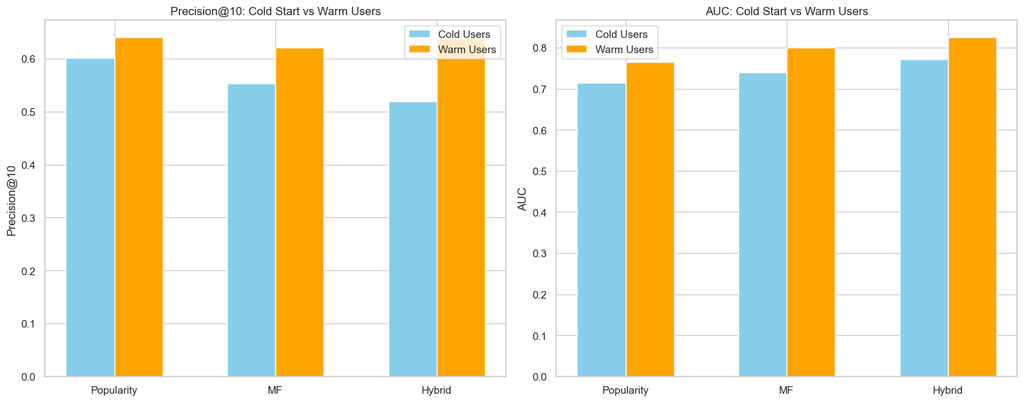

```python
def analyze_user_groups(test_data, train_pos, score_fn_dict, threshold=5):
    user_counts = Counter()
    for u, i in train_pos:
        user_counts[u] += 1
    cold_data = []
    warm_data = []
    for row in test_data:
        u = row['u']
        if user_counts[u] <= threshold:
            cold_data.append(row)
        else:
            warm_data.append(row)

    print(f'{threshold=}, {len(cold_data)=}, {len(warm_data)=}')

    group_results = {}
    for name, fn in score_fn_dict.items():
        auc_cold, p_cold = eval_model(fn, cold_data, k=10)
        auc_warm, p_warm = eval_model(fn, warm_data, k=10)
        group_results[name] = (p_cold, p_warm, auc_cold, auc_warm)

    return group_results

models_to_compare = {
    "Popularity": pop_score,
    "MF": mf_score,
    "Hybrid": hybrid_best
}

group_res = analyze_user_groups(test_data, train_pos, models_to_compare)

labels = list(group_res.keys())
cold_scores_p = [group_res[m][0] for m in labels]
warm_scores_p = [group_res[m][1] for m in labels]
cold_scores_auc = [group_res[m][2] for m in labels]
warm_scores_auc = [group_res[m][3] for m in labels]

x = np.arange(len(labels))
width = 0.3

fig, (ax1, ax2) = plt.subplots(1, 2, figsize=(15, 6))

ax1.bar(x - width/2, cold_scores_p, width, label='Cold Users', color='skyblue')
ax1.bar(x + width/2, warm_scores_p, width, label='Warm Users', color='orange')
ax1.set_ylabel('Precision@10')
ax1.set_title('Precision@10: Cold Start vs Warm Users')
ax1.set_xticks(x)
ax1.set_xticklabels(labels)
ax1.legend()

ax2.bar(x - width/2, cold_scores_auc, width, label='Cold Users', color='skyblue')
ax2.bar(x + width/2, warm_scores_auc, width, label='Warm Users', color='orange')
ax2.set_ylabel('AUC')
ax2.set_title('AUC: Cold Start vs Warm Users')
ax2.set_xticks(x)
ax2.set_xticklabels(labels)
ax2.legend()

plt.tight_layout()
plt.show()
```

```
Catalog Coverage (Popularity): 16.1163% (28814 unique items)
Catalog Coverage (Hybrid):     58.1214% (103914 unique items)
```

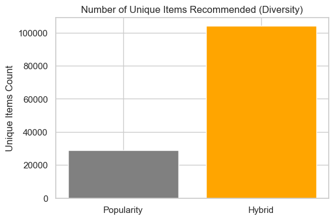

```python
def calculate_catalog_coverage(model_func, test_data, all_items_count, k=10):
    recommended_items = set()
    for row in test_data:
        u = row['u']
        candidates = [row['pos']] + row['negs']
        scores = [(i, model_func(u, i)) for i in candidates]
        scores.sort(key=lambda x: x[1], reverse=True)
        top_k = [i for i, _ in scores[:k]]
        recommended_items.update(top_k)

    coverage = len(recommended_items) / all_items_count
    return coverage, len(recommended_items)
cov_pop, count_pop = calculate_catalog_coverage(pop_score, test_data, num_items)
cov_hyb, count_hyb = calculate_catalog_coverage(hybrid_best, test_data, num_items)

print(f"Catalog Coverage (Popularity): {cov_pop:.4%} ({count_pop} unique items)")
print(f"Catalog Coverage (Hybrid):     {cov_hyb:.4%} ({count_hyb} unique items)")

plt.figure(figsize=(6, 4))
plt.bar(['Popularity', 'Hybrid'], [count_pop, count_hyb], color=['gray', 'orange'])
plt.title("Number of Unique Items Recommended (Diversity)")
plt.ylabel("Unique Items Count")
plt.show()
```

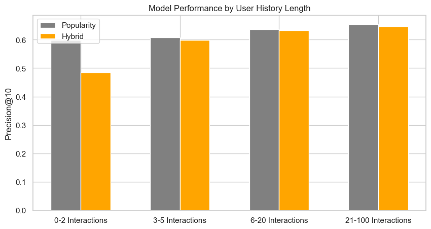

```python
def analyze_performance_by_bins(test_data, train_pos, score_fn, bins=[(0,5), (6,20), (21, 1000)]):
    user_counts = Counter()
    for u, i in train_pos:
        user_counts[u] += 1

    bin_results = []
    bin_labels = []

    for (low, high) in bins:
        subset = [row for row in test_data if low <= user_counts[row['u']] <= high]

        if len(subset) == 0:
            bin_results.append(0)
        else:
            _, p_10 = eval_model(score_fn, subset, k=10)
            bin_results.append(p_10)

        bin_labels.append(f"{low}-{high} Interactions")

    return bin_labels, bin_results

bins = [(0, 2), (3, 5), (6, 20), (21, 100)]
labels, res_pop = analyze_performance_by_bins(test_data, train_pos, pop_score, bins)
_, res_hyb = analyze_performance_by_bins(test_data, train_pos, hybrid_best, bins)

x = np.arange(len(labels))
width = 0.3

plt.figure(figsize=(10, 5))
plt.bar(x - width/2, res_pop, width, label='Popularity', color='gray')
plt.bar(x + width/2, res_hyb, width, label='Hybrid', color='orange')
plt.xticks(x, labels)
plt.ylabel('Precision@10')
plt.title('Model Performance by User History Length')
plt.legend()
plt.show()
```

## 5. Related Work

Our project fits into a long line of research on systems that suggest items to users based on their past behavior, such as likes or clicks, and on using image information to make better recommendations.

**Using past likes and clicks to make recommendations:**  
Many existing systems only see whether a user clicked or liked something, not a detailed rating. Early work such as *Collaborative Filtering for Implicit Feedback Datasets* (Hu, Koren, & Volinsky, 2008) and *BPR: Bayesian Personalized Ranking from Implicit Feedback* (Rendle, Freudenthaler, Gantner, & Schmidt-Thieme, 2009) showed how to use this kind of “yes/no” data to learn which users and items go well together. Their models learn a small list of numbers for each user and for each item, and then give a higher score to user–item pairs whose numbers line up well. At prediction time, the system picks the items with the highest scores for each user. Our main interaction based model is inspired by this same idea, where for each user and each project, we learn a short numeric description, and to recommend projects to a user we score all projects and keep the ones with the highest scores.

**Using image information to make recommendations:**  
More recent research combines interaction data with information extracted from the images themselves. In domains like fashion, art, and design, how something looks is very important, so using image information can help. Models such as VBPR (*VBPR: Visual Bayesian Personalized Ranking for Personalized Recommendation of Visual Content*; He & McAuley, 2016) use an image recognition network to turn each image into a long vector of numbers that captures aspects like style, color, and composition. They then combine this image based description with the interaction based model so that the system can recommend items that both match a user’s taste and look similar to things they have liked before, and can still recommend reasonable items even when there are few past likes for a given item. Other work on image popularity prediction, such as *What Makes an Image Popular?* (Khosla, Das Sarma, & Hamid, 2014), also shows that these kinds of image features are strongly related to whether an image will attract attention and engagement.

Our visual only model is closest to this line of work on image popularity. In our case, we ignore user IDs and only look at image-based features, since we build a visual profile for each user by averaging the image features of the projects they liked, and then recommend projects whose image features are similar to that profile. We find that this image only approach does contain useful information, but it is not enough by itself: compared to our interaction-based model and our popularity based model, it suggests fewer projects that the user actually likes near the top of the ranked list.